# MAESTRÍA EN ESTADÍSTICA APLICADA/ MANEJO DE DATOS

**Unidad 4: Selección, limpieza y transformación de datos**

**4.3 Limpieza de datos utilizando funciones de Rstudio**

En un proyecto de Ciencias de Datos, es fundamental realizar un procesamiento previo de limpieza y transformaciones necesaria, de tal forma, la data quede lista para su posterior procesamiento análisis de los mismos, por medio de distintos estadísticos y gráficos que permitan describir las variables con las que se trabaja y determinar las posibles relaciones entre ellas. La calidad del conjunto de datos finalmente obtenido determinará la robustez y fiabilidad de los resultados del proyecto.

**4.3.1 Manejo de String**

Es común encontrarse problemas en campos tipo cadena de caracteres (string), tales como: espacios en blancos en los extremos, caracteres que no pertenecen a un patrón o formato, divición o separación de contendio de un campo, estandarizar contenido, entre otros.

Para el procesamiento de cadenas de caracteres, se requiere el uso de la librería stringr.

```r
library(stringr)
```

Para la aplicación de los siguientes funciones de limpieza de datos, supongamos que se dispone una tabla de datos de empleados:

Los datos se encuentran en el archivo Empleados.csv, por lo que se deben leer desde esa fuente.

```r
df_emp<- read.csv("C:/Users/marcelochavez/Documents/MAESTRIA_ESTADISTICA_APLICADA_ESPOL/MODULO_2/TALLER_1JULIO2023/Empleados.csv", sep=";", stringsAsFactors=FALSE)
str(df_emp)
```

```
'data.frame':   5 obs. of  7 variables:
 $ DNI             : int  123456789 234567891 345678912 456789123 567891234
 $ Nombres         : chr  "Carlos Daniel Macias Torres" "ADRIANA VALENTINA FLORES MORA" "LORENA Vanessa Pe\xf1a Lino" "GALO TONY DURANGO RIOS" ...
 $ CiudadResidencia: chr  "      Guayaquil" "Ambato" "  Manta" "Quito    " ...
 $ FechaNacimiento : chr  "10/5/1985" "4/6/1986" "18/12/1990" "10/10/1975" ...
 $ AniosLabor      : chr  "15 a\xf1os" "10 a\xf1os" "5 a\xf1os" "20 a\xf1os" ...
 $ Remuneracion    : int  2500 2000 1300 3400 2000
 $ Code            : chr  "111e" "e456" "893" "567" ...
```

**Estado original de la data:**

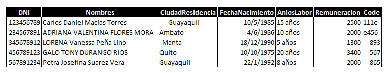

Data sucia

**Eliminación de espacios en blancos en los extremos**

Se puede observar en la tabla de datos, que en el campo Ciudad de Residencia, existen espacios en blancos al inicio y final. Para eliminar los espacios en blanco se utiliza la función str_trim(string=[cadena de texto], side=c(“left”,“right”,“both”) )

```r
df_emp$CiudadResidencia<-str_trim(string = df_emp$CiudadResidencia, side = "both")
View(df_emp)
```

**Dividir el contenido de un campo**

En el caso del campo fecha, fue cargado desde la fuente de origen como tipo string, pero es conveniente separar los elementos de la fecha en tres campos distintos. La función que nos permite realizar dicha acción es str_split_fixed(string = [cadena de texto], pattern = “[char]”, n=[cantidad de partes]). Esta función permite crear una matriz con las partes obtenidas de la segmentación del contenido.

```r
str_split_fixed(string = df_emp$FechaNacimiento, pattern = "/", n=3)
```

```
     [,1] [,2] [,3]
[1,] "10" "5"  "1985"
[2,] "4"  "6"  "1986"
[3,] "18" "12" "1990"
[4,] "10" "10" "1975"
[5,] "22" "1"  "1992"
```

Para asignar cada fila en el Dataframe, podemos utilzar la notación matricial [,columna], de la siguiente forma:

```r
df_emp$dia<-str_split_fixed(string = df_emp$FechaNacimiento, pattern = "/", n=3)[,1]
df_emp$mes<-str_split_fixed(string = df_emp$FechaNacimiento, pattern = "/", n=3)[,2]
df_emp$anio<-str_split_fixed(string = df_emp$FechaNacimiento, pattern = "/", n=3)[,3]
df_emp
```

Otra forma de separar contenido de un campo, es utilizar la función separate() de la library(tidyr), esto lo revisaremos en la siguiente sección.

**Extraer fragmentos de una cadena que corresponden a un determinado patrón**

Como se puede observar en la tabla de datos de Empleados, existe el campo años de labor como tipo texto, nos interaría tomar solo el componente numérico de dicho contenido.

```r
formato<-"[0-9]+"  #formato de uno o más números desde el inicio de la cadena
df_emp$tiempo<-str_extract(string = df_emp$AniosLabor, pattern = formato)
df_emp
```

**Reemplazar/suprimir contenido parcial**

En el caso que se requiera reemplazar o suprimir contenido parcial en una cadena de texto, se puede utilizar la función gsub(). Como se puede observar en la tabla de Empleados, el campo Code tiene un caracter incorrecto “e”, se desea suprimir dicho contenido, para lo cual, se utiliza la función gsub(“formato”,“reemplazo”, datos).

```r
gsub("e","",df_emp$Code)
```

Ahora se debe actualizar el contenido del campo:

```r
df_emp$Code<-gsub("e","",df_emp$Code)
```

**Homogenizar mayúsculas/ minúsculas**

Si observamos el campo de nombre en la tabla Empleados, nos podemos percatar que algunos se muestran en mayúsculas y otros no, por tal razón, si por procesamiento es necesario homogenizar dicho contenido, se puede utilizar las funciones str_to_upper() o str_to_lower().

```r
df_emp$Nombres<-str_to_upper(string = df_emp$Nombres)
```

**4.3.2 Manejo de Fechas**

El procesamiento de campos tipo fecha también es importante darle un orden correspondiente. En la tabla Empleados existe el campo “Fecha de Nacimiento”, el tipo de dato origen de este campo en texto, sin embargo se lo requiere convertir en tipo date para utilizar las funciones de procesamiento de fechas. Para realizar la conversión se utiliza el comando as.Date().

El formato que se utilizará para el campo fecha es %d/%m/%Y.

```r
df_emp$FechaNac2<-as.Date(df_emp$FechaNacimiento,format="%d/%m/%Y")
```

En caso de requerir que el nombre del mes se incorpore como una columna adicional, se puede utilizar la función format(campo,formato):

```r
df_emp$nmes<-format(df_emp$FechaNac2,"%B")
```

```r
fecha_actual=Sys.Date()
difftime(fecha_actual,df_emp$FechaNacimiento, units = "days" )
```

Para el procesamiento de datos de fecha también se puede aplicar las funciones del paquete lubridate.

**lubridate**

Con esta librería resulta muy sencillo trabajar con fechas y horas. Nos permite convertir cadenas de caracteres al formato de fecha POSIXct, reconociendo distintos formatos. Algunos ejemplos:

– Año, mes y día separados por guiones o barras

```r
#install.packages("lubridate")
library(lubridate)
fechas <- c("2017-05-03", "2017/05/03")
ymd(fechas)
```

– Día, mes y año sin separación o incluso escritos (en inglés)

```r
fechas <- c("03052017", "3 May 2017")
dmy(fechas)
```

– Fechas y horas, pudiendo indicar la zona horaria

```r
ymd_hms("2017-05-03 09:00:00", tz = "America/Bogota")
```